# Analysing DNA methylation data with Bioconductor

9 September 2015

## Basic biology

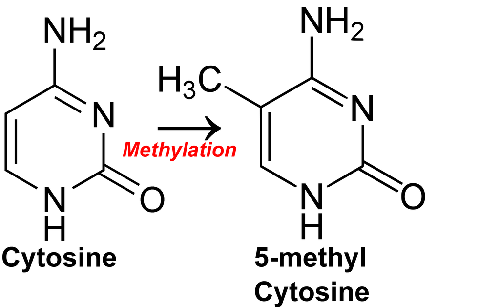

Modified "[Cytosine becomes thymine](https://commons.wikimedia.org/wiki/File:Cytosine_becomes_thymine.png#/media/File:Cytosine_becomes_thymine.png)" by CFCF - Own work. Licensed under [CC BY-SA 3.0](http://creativecommons.org/licenses/by-sa/3.0) via Wikimedia Commons.

## Basic biology

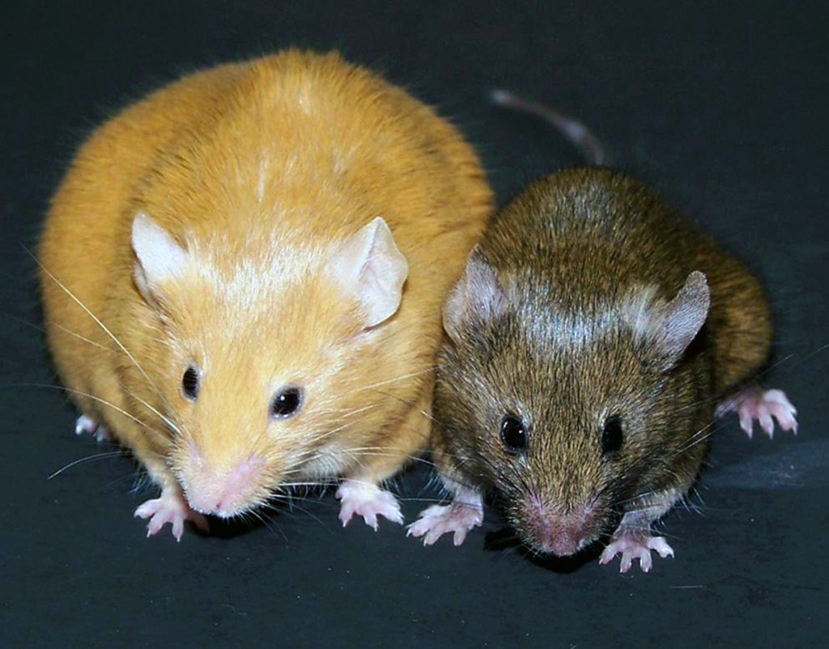

http://episona.com/wp-content/uploads/2014/01/Agouti-Mouse-1024x802.jpg

## Basic biology

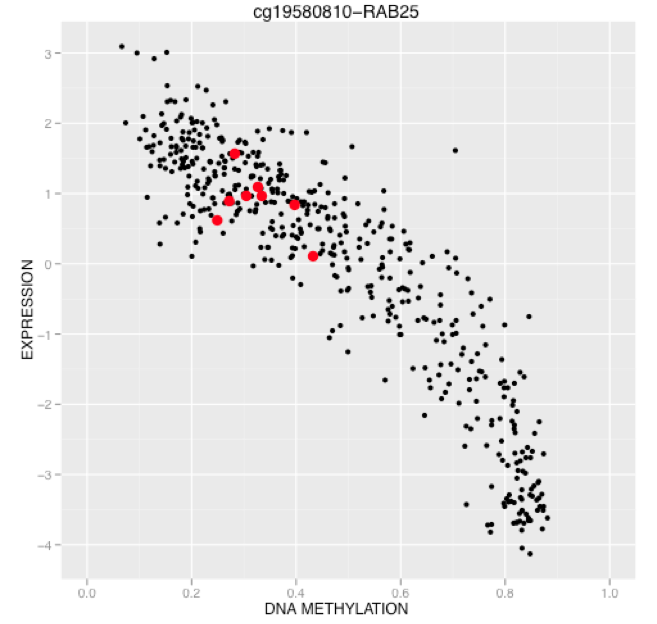

Figure S7.1C, Integrated genomic analyses of ovarian carcinoma, TCGA, doi:10.1038/nature10166

## Sodium bisulfite treatment of DNA

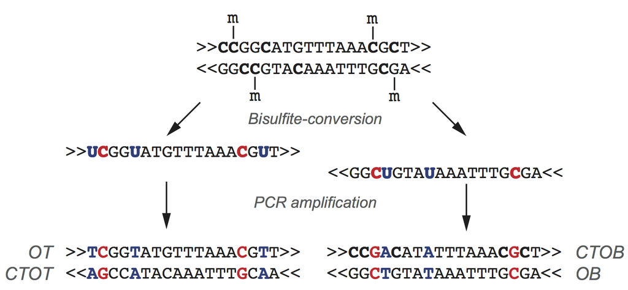

## Assays

## Bisulfite-based assays

Going to focus on contemporary high-throughput assays based on **sodium bisulfite treatment of DNA**

### Microarrays

- Illumina 27k
- Illumina 450k

### Sequencing

- Whole-genome bisulfite-sequencing (WGBS/BS-seq/methylC-seq)
- (Enhanced/Extended) Reduced representation bisulfite-sequencing (eRRBS/RRBS)
- Capture + bisulfite-sequencing (Roche SeqCap Epi system)

## Non-bisulfite assays

Based on an enrichment/pulldown of methylated DNA and/or restriction enzymes

- **Me**thylated DNA **i**mmuno**p**recipitation + microarray/sequencing (MeDIP-microarray/MeDIP-seq/mDIP-seq)
- **M**ethylation-sensitive **r**estriction **e**nzyme + sequencing (MRE-seq)
- **M**ethyl **b**inding **d**omain protein-enrichment + sequencing (MBD-seq)

## The analysis pipeline

Most assay-specific:

- Getting data into R
- Pre-processing
- Analysis

Somewhere in between:

- Batch effects

Less assay-specific:

- Visualisation
- Data integration

## How can Bioconductor help?

Bioconductor 3.1 packages (based on DNAMethylation [*BiocViews*](http://www.bioconductor.org/packages/release/BiocViews.html)):

- 42 software packages
- 6 annotation packages

## Disclaimer

**I can't tell you everything**

- 25 minutes
- I don't know everything!

**Will tell you:**

- What I find useful as a fairly well-experienced user & developer
- What I am most familiar with
- Where to find out more

## Microarrays

## Description of assays

### What these measure

- Red + green fluorescence intensities

### [Illumina 27k](https://en.wikipedia.org/wiki/Illumina_Methylation_Assay)

- Infinium HumanMethylation27 BeadChip
- ~28,000 cytosines
- Mostly in promoters of ~15,000 genes
- Infinium I probes
- Deprecated? But much of TCGA data uses this platform.

### [Illumina 450k](http://www.illumina.com/products/methylation_450_beadchip_kits.html)

- Infinium HumanMethylation450 BeadChip
- ~486,000 cytosines
- Promoters, gene bodies, 3' UTR, intergenic
- 135k Infinium I and 350k Infinium II probes
- [An overview of 450k technology](http://www.biostat.jhsph.edu/~lcollado/misc/genomics/GWG_JPF.pdf)

## Key packages

### Powerhouses

- [*minfi*](http://bioconductor.org/packages/minfi/)
- [*methylumi*](http://bioconductor.org/packages/methylumi/)

### Pipelines

- [*ChAMP*](http://bioconductor.org/packages/ChAMP/)
- [*RnBeads*](http://bioconductor.org/packages/RnBeads/)

## Data ingest

### File formats

- `.idat` files
- Files returned by Illumina's BeadStudio

### [*minfi*](http://bioconductor.org/packages/minfi/)

- `read.450k()`, `read.450k.exp()`, `read.450k.sheet()`
- `readTCGA()`
- `readGEORawFile()`

## Pre-processing

**Very important**

See [A comprehensive overview of Infinium HumanMethylation450 data processing (2013)](http://bib.oxfordjournals.org/content/15/6/929.long), [minfi User's Guide](http://www.bioconductor.org/packages/release/bioc/vignettes/minfi/inst/doc/minfi.pdf)

## Quality control

### Static

- `minfi::qcReport()`, `minfi::minfiQC()`
- [*skewr*](http://bioconductor.org/packages/release/bioc/html/skewr.html)

### Interactive

- [*MethylAid*](http://bioconductor.org/packages/release/bioc/html/MethylAid.html)
- [*shinyMethyl*](http://bioconductor.org/packages/shinyMethyl/)

[figure not shown]

## Pre-processing

### Standard microarray issues

- Failed probes
- Cross-reactive probes
- Background correction
- Colour (dye) bias adjustment
- Normalisation

### 450k-specific issues

- Type I and II probes are very different
- CpG-SNPs

### Methylation-specific(ish) issues

- Cell composition artefacts

## Pre-processing

- Several pre-processing options available in Bioconductor packages and some comparisons published e.g., [wateRmelon](http://bioconductor.org/packages/wateRmelon/)

### Tools

- [*minfi*](http://bioconductor.org/packages/minfi/)
  - `detectionP()`
  - `preprocessRaw()`, `preprocessIllumina()`, `preprocessQuantile()`, `preprocessNoob()`, `preprocessSWAN()`, `preprocessFunnorm()`
  - `dropLociWithSnps()`
  - `estimateCellCounts()`
- [*RUVm* (remove unwanted variation)](http://www.bioconductor.org/packages/release/bioc/vignettes/missMethyl/inst/doc/missMethyl.pdf) implemented in [*missMethyl*](http://bioconductor.org/packages/missMethyl/)
- [*CopyNumber450k*](http://bioconductor.org/packages/CopyNumber450k/)

## Downstream analyses

### \(\beta\)-values vs. \(\mathcal{M}\)-values

\(\beta = \frac{M}{M + U + 100} \in [0, 1]\)

\(\mathcal{M} = \log(\frac{M}{U}) \in [-\infty, \infty]\)

[Du, P. et al. Comparison of Beta-value and M-value methods for quantifying methylation levels by microarray analysis. BMC Bioinformatics 11, 587 (2010).](http://www.ncbi.nlm.nih.gov/pmc/articles/PMC3012676/):

> "We recommend using the \(\mathcal{M}\)-value method for conducting differential methylation analysis and including the \(\beta\)-value statistics when reporting the results to investigators."

## Differential methylation

### Differentially methylated probes (DMPs)

- For a given probe, are the group-average level(s) of methylation different?
- [*limma*](http://bioconductor.org/packages/limma/) is the workhorse, e.g., `minfi::dmpFinder()`
- **OPINION**: You want a pretty good reason not to use a *limma*-based approach

### Differentially methylated regions (DMRs)

- Identify *regions* with different group-average level(s) of methylation
- **OPINION**: DMR finding/testing is somewhat *ad hoc*, but getting better
- E.g., see `minfi::blockFinder()` with the `bumphunter::bumphunter()` backend

## Differential variability

- For a given probe, are the within-group variances of methylation levels different?
- `missMethyl::varFit`, `missMethyl::topVar()` based on [*limma*](http://bioconductor.org/packages/limma/)

## Description of assays

Bisulfite-sequencing-based assays

- WGBS
- [e]RRBS

Enrichment-based assays

- MeDIP-seq
- MREseq
- Not going to talk about much

## Key packages

- Sequencing
- Bisulfite-sequencing
- BiSeq
- bsseq
- DMRcaller
- DSS
- M3D
- methylPipe
- MethylSeekR
- MPFE

## Analysis pipeline

- Non-R stuff: pre-processing, mapping, and post-processing of reads
- List popular alignment software
- M-bias
- Data input
- Pre-processing
- CpG-SNPs
- CNVs
- Normalisation
- Downstream analyses
- Smoothing
- Beta-binomial model
- Differential methylation: DMLs/DMPs, DMRs, kernel based tests.
- Differential variability
- Methylation patterns

## Visualisation

## Yup

- epiviz
- lollipop plots

## Data integration

## Yup

- AnnotationHub, biomaRt, etc.

## Batch effects and technical biases

## Yup

- Cell composition bias

## Miscellaneous

## Yup

- Single-cell assays

## Links

## Yup

- Workflows
- Package vignettes
- Slides
- Conferences (e.g., http://webspace.qmul.ac.uk/rlowe/450kworkshop//index.html)
- [PH525x series - Biomedical Data Science](http://genomicsclass.github.io/book/)
- [A comprehensive overview of Infinium HumanMethylation450 data processing](http://www.ncbi.nlm.nih.gov/pmc/articles/PMC4239800/)
- [Evaluation of the Infinium Methylation 450K technology](http://www.ncbi.nlm.nih.gov/pubmed/22126295)
- [Validation of a DNA methylation microarray for 450,000 CpG sites in the human genome (pdf)](http://www.tandfonline.com/doi/pdf/10.4161/epi.6.6.16196)
- https://www.coursera.org/course/genbioconductor

## TODOs

- [ ] Include affiliation on title slide?
- [ ] Note that this is an opinionated talk
- [ ] Add authors to key packages?

## Manual package curation

**TODO: Working notes, not an actual slide**

## Key packages

### Microarrays

- BEclear (batch effects)
- ChAMP
- charm
- COHCAP (+ BS-seq)
- conumee
- CopyNumber450k
- DMRcate
- DMRforPairs
- ENmix
- lumi
- MethylAid
- MethylMix
- methylumi
- minfi
- missMethyl
- shinyMethyl
- skewr
- wateRmelon
- **ANNOTATION**

### Misc.

- bumphunter (general)
- coMET (visualisation of EWAS and 'co-methylation LD maps')
- MassArray (sequenom)
- MEDIPS (MeDIP-seq)
- MEDME (MeDIP-microarray)
- methVisual (clone BS-seq)
- methyAnalysis (mostly arrays with some seq, same dev as lumi)
- methylMnM (MeDIP-seq and MRE-seq)
- Repitools (MeDIP-seq)
- RnBeads (box and dice, slick pipeline run with "modules", uses other packages)